# RFM Analysis

David Cortes

March 27, 2016

This project consists in using transaction data from an online application (software) to calculate the lifetime value of customers, see which customers are at risk of defecting and finding segments (groups of similar users) from the users that are still active, based on RFM analysis (Recency-Frequency-Monetary). The data comes in the form of a table with columns User ID, date of install, date of payment and transaction amount. The algorithms are described in [“Counting your customers” the easy way: An alternative to the Pareto/NBD model](http://brucehardie.com/papers/018/fader_et_al_mksc_05.pdf) and [RFM and CLV: Using iso-value curves for customer base analysis](http://brucehardie.com/papers/rfm_clv_2005-02-16.pdf).

Transactions can happen at any moment and so one of the problems is identifying whether a given user is still active (i.e. will pay again) or not. In this regard, the date of the last transactions and the frequency with which previous transactions from this user happened can help to build a probabilistic model for future transactions.

From this, residual lifetime value can be estimated by summing the expected future transactions and applying a discount rate to them, according to how far in the future they will happen.

The analyses performed here consider transactions on a weekly basis (i.e. did at least one transaction occur this week or not), since this leads to better predictive performance than using daily data.

# 1 . Loading and Formatting the Data

```r
#loading the data
gt <- read.csv("data.csv", sep=";")

gt$transaction_date=as.Date(gt$transaction_date,"%d.%m.%Y")
gt$install_date=as.Date(gt$install_date,"%d.%m.%Y")
gt$value=gt$value/100
head(gt,10)
```

```
##    value transaction_date install_date          id
## 1    200       2013-11-04   2013-08-14 2,00006E+11
## 2    100       2013-11-07   2013-08-14 2,00006E+11
## 3     20       2013-11-01   2013-08-14 2,00006E+11
## 4     50       2013-11-01   2013-08-14 2,00006E+11
## 5     50       2013-11-01   2013-08-14 2,00006E+11
## 6    100       2013-09-10   2013-08-14 2,00006E+11
## 7     50       2013-09-10   2013-08-14 2,00006E+11
## 8    100       2013-08-25   2013-08-14 2,00006E+11
## 9    200       2013-09-04   2013-08-14 2,00006E+11
## 10   300       2013-08-19   2013-08-14 2,00006E+11
```

# 2. Examining the relationship between average transaction value and frequency of transactions

```
## [1] "Correlations between: "
```

```
## [1] "Number of purchases and average transaction value: 0.12"
```

```
## [1] "Number of days with purchases and average money spent in a day: 0.17"
```

```
## [1] "Number of weeks with purchases and average money spent in a week: 0.17"
```

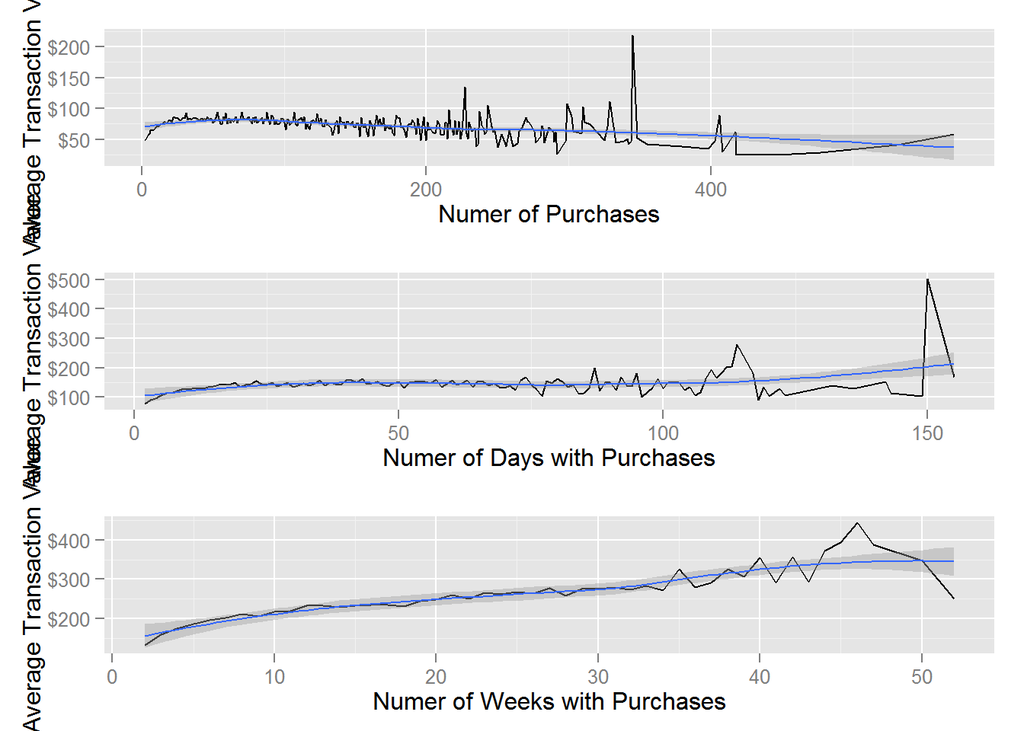

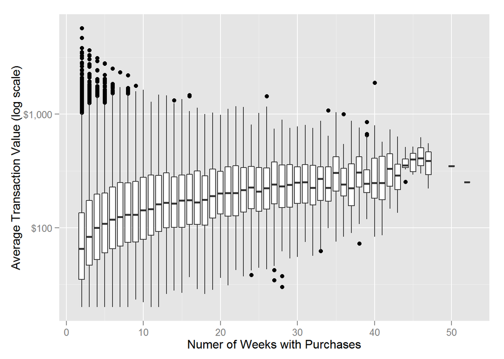

```r
#examining the relationship between average transaction value and number of transactions (total, by day and by week)
library(dplyr)
library(ggplot2)
library(gridExtra)
library(scales)
freq.value.total=gt %>% group_by(id) %>% summarize(freq=n(),val=mean(value)) %>% select(-id) %>% filter(freq>1)
freq.value.day=gt %>% group_by(id,transaction_date) %>% summarize(value=sum(value)) %>% group_by(id) %>% summarize(freq=n(),val=mean(value)) %>% select(-id) %>% filter(freq>1)
freq.value.week=gt %>% mutate(transaction_date=as.integer(difftime(transaction_date,min(transaction_date),units="weeks"))) %>% group_by(id,transaction_date) %>% summarize(value=sum(value)) %>% group_by(id) %>% summarize(freq=n(),val=mean(value)) %>% select(-id) %>% filter(freq>1)

pl=freq.value.total %>% group_by(freq) %>% summarize(value=mean(val))
p1=ggplot(pl,aes(freq,value))+geom_line()+geom_smooth()+scale_y_continuous(labels=dollar)+ylab("Average Transaction Value")+xlab("Numer of Purchases")
pl=freq.value.day %>% group_by(freq) %>% summarize(value=mean(val))
p2=ggplot(pl,aes(freq,value))+geom_line()+geom_smooth()+scale_y_continuous(labels=dollar)+ylab("Average Transaction Value")+xlab("Numer of Days with Purchases")
pl=freq.value.week %>% group_by(freq) %>% summarize(value=mean(val))
p3=ggplot(pl,aes(freq,value))+geom_line()+geom_smooth()+scale_y_continuous(labels=dollar)+ylab("Average Transaction Value")+xlab("Numer of Weeks with Purchases")
grid.arrange(p1,p2,p3)

ggplot(freq.value.week,aes(freq,val,group=freq))+geom_boxplot()+scale_y_log10(labels=dollar)+ylab("Average Transaction Value (log scale)")+xlab("Numer of Weeks with Purchases")

#examining correlation numbers
print("Correlations between: ");paste0("Number of purchases and average transaction value: ",round(cor(freq.value.total)[2],2));paste0("Number of days with purchases and average money spent in a day: ",round(cor(freq.value.day)[2],2));paste0("Number of weeks with purchases and average money spent in a week: ",round(cor(freq.value.week)[2],2))
```

There seems to be a correlation between these two, but it’s small in relationship to the huge variability in average transaction values and tends to level-off with number of transactions, so it’s probably still adequate to use models for estimating number of transactions and using a constant transaction value for LTV.

# 3. Evaluating different models for predicting transactions

```r
#examining different models for LTV taking as a cohort the customers that made a transaction during the first week
library(BTYD)

#taking the cohort
sample.cohort=gt %>% mutate(week=as.integer(difftime(transaction_date,min(transaction_date),units="weeks"))) %>% group_by(id) %>% summarize(first=min(week)) %>% filter(first==0) %>% select(-first)

sample.cohort=gt$id %in% sample.cohort$id
print(paste0("Number of transactions in the sample cohort: ",paste0(round(sum(sample.cohort)*100/dim(gt)[1],2),"%")))

#splitting the data into calibration/holdout period
split.date=as.Date("2014-03-06")
gt.sample=gt[sample.cohort,]
elog.day=data.frame(cust=gt.sample$id,date=gt.sample$transaction_date,sales=gt.sample$value)

#generating useful data by day
m1.data=dc.ElogToCbsCbt(elog.day,per="day",T.cal = split.date,merge.same.date = TRUE)
m2.data=dc.ElogToCbsCbt(elog.day,per="day",T.cal = split.date,merge.same.date = FALSE)

#generating useful data by week
starting.date=min(gt$transaction_date)
gt.sample=gt.sample %>% mutate(transaction_date=as.integer(difftime(transaction_date,min(transaction_date),units="weeks"))) %>% group_by(id,transaction_date) %>% summarize(value=sum(value)) %>% mutate(transaction_date=starting.date+7*transaction_date)
elog.week=data.frame(cust=gt.sample$id,date=gt.sample$transaction_date,sales=gt.sample$value)
m3.data=dc.ElogToCbsCbt(elog.week,per="week",T.cal = split.date,merge.same.date = TRUE,statistic="freq")

#this was taken from the BTYD guide
tot.cbt=dc.CreateFreqCBT(elog.day)
d.track.data=rep(0,370)
for (i in colnames(tot.cbt)){
  date.index= difftime(as.Date(i),starting.date)+1
  d.track.data[date.index]=sum(tot.cbt[,i])
}
w.track.data=rep(0,floor(370/7))
for (j in seq(1,floor(370/7))){
  w.track.data[j]=sum(d.track.data[(j*7-6):(j*7)])
}
```

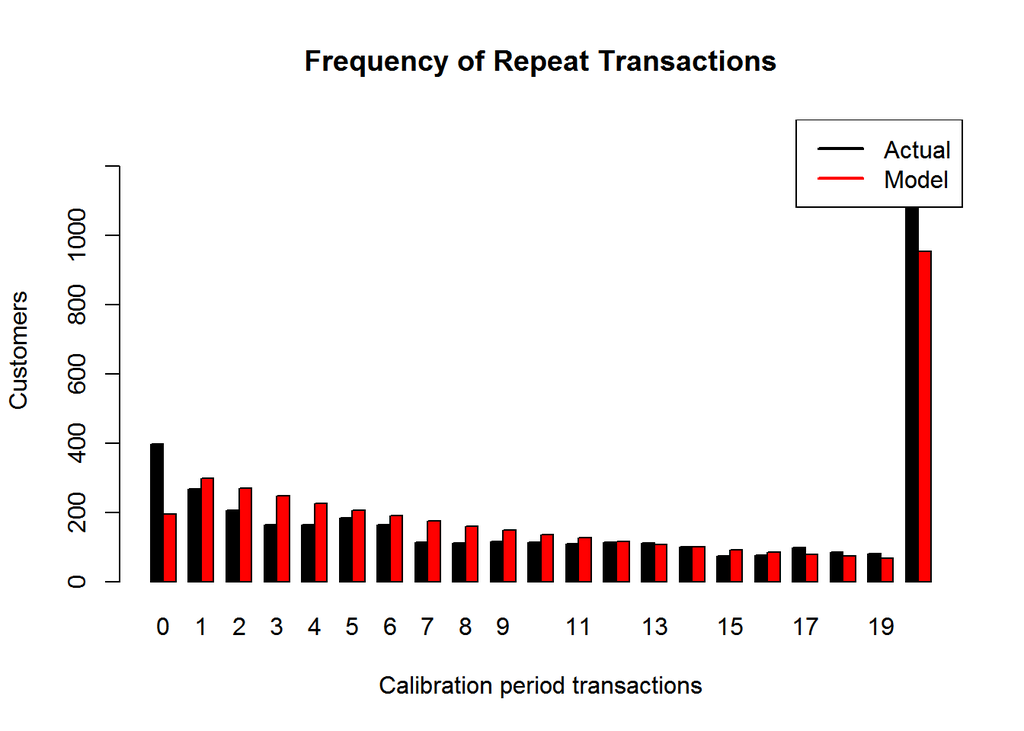

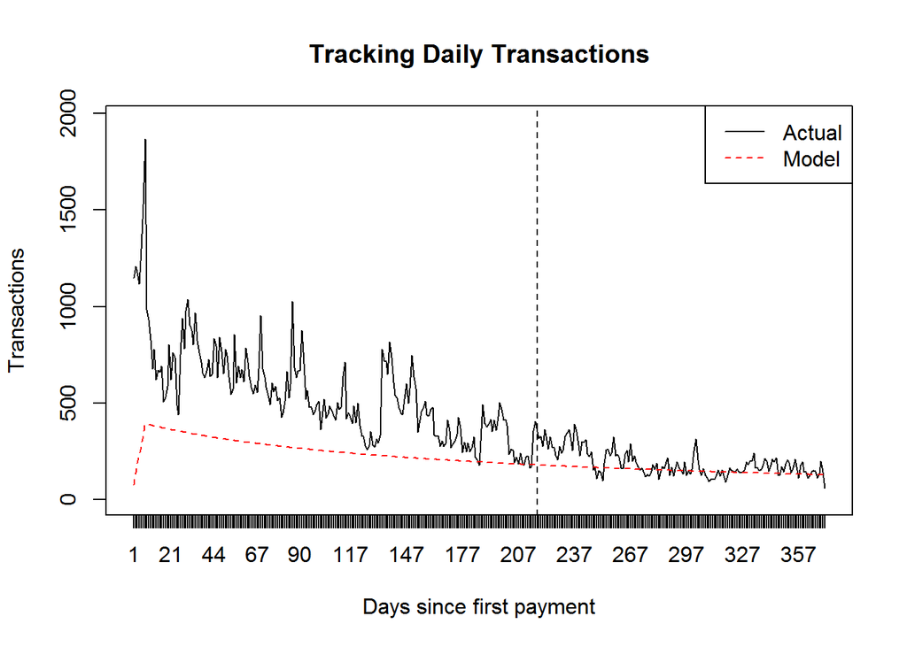

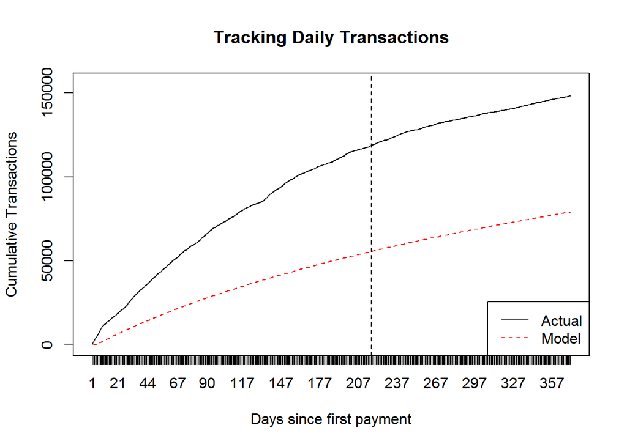

```r
##########
#bg/nbd model by day, grouping transactions
#estimating parameters
m.bgnbd.day=bgnbd.EstimateParameters(m1.data$cal$cbs)

#checking its fit
invisible(bgnbd.PlotFrequencyInCalibration(m.bgnbd.day,m1.data$cal$cbs,20))

#checking predictive performance
invisible(bgnbd.PlotTrackingInc(m.bgnbd.day,m1.data$cal$cbs[,"T.cal"],370,d.track.data,title="Tracking Daily Transactions",xlab="Days since first payment"))
invisible(bgnbd.PlotTrackingCum(m.bgnbd.day,m1.data$cal$cbs[,"T.cal"],370,cumsum(d.track.data),title="Tracking Daily Transactions",xlab="Days since first payment")
)

##the model had a poor fit and poor predictive power
```

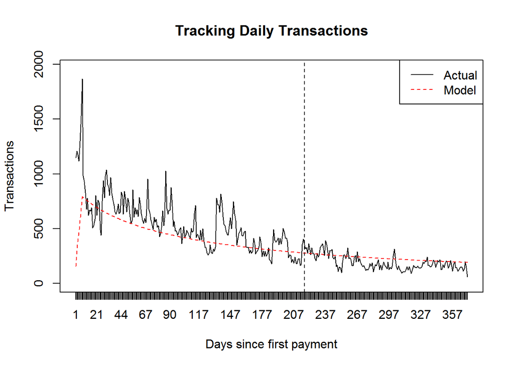

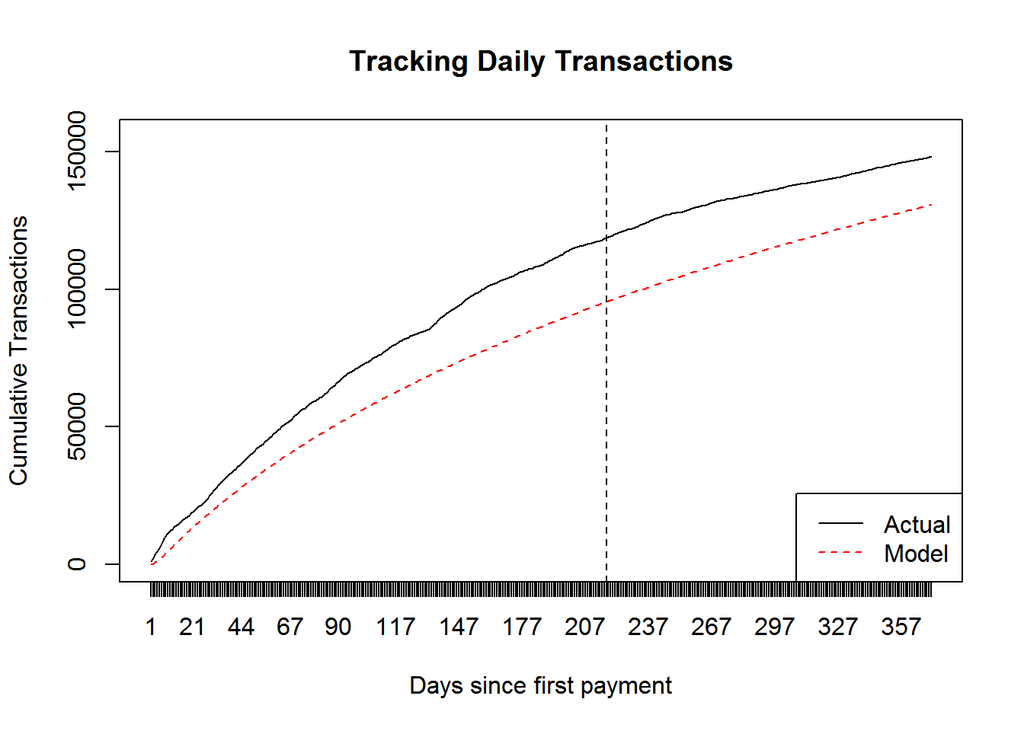

```r
#########
#bg/nbd model by day, without grouping transactions
m.bgnbd.day2=bgnbd.EstimateParameters(m2.data$cal$cbs)
invisible(bgnbd.PlotTrackingInc(m.bgnbd.day2,m2.data$cal$cbs[,"T.cal"],370,d.track.data,title="Tracking Daily Transactions",xlab="Days since first payment"))
invisible(bgnbd.PlotTrackingCum(m.bgnbd.day2,m2.data$cal$cbs[,"T.cal"],370,cumsum(d.track.data),title="Tracking Daily Transactions",xlab="Days since first payment"))

##this model fared somewhat better
```

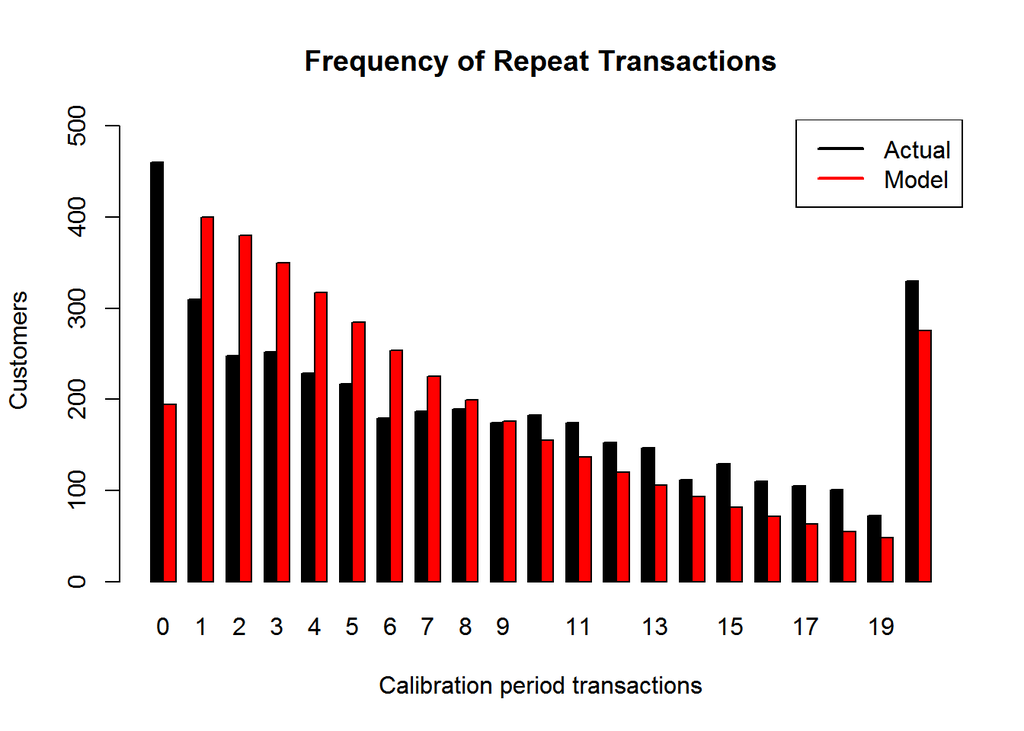

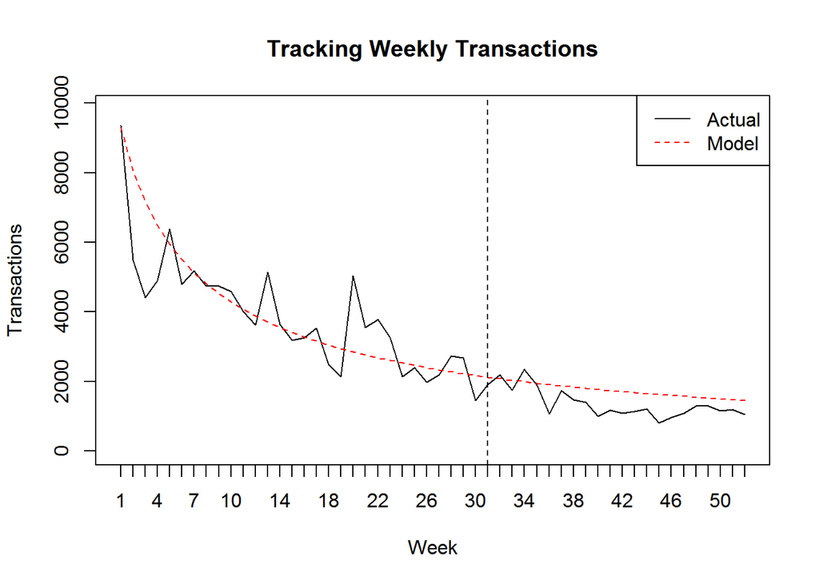

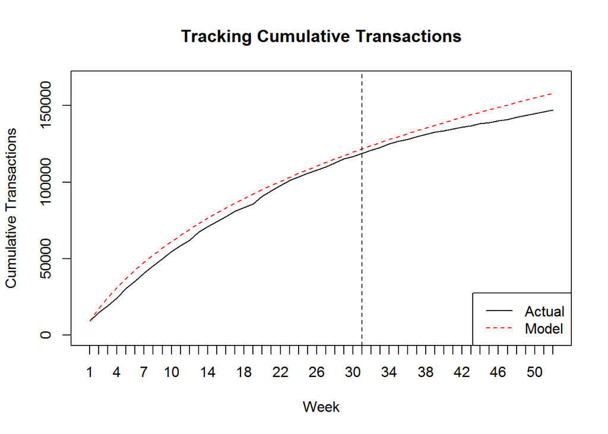

```r
#bg/nbd model by week
m.bgnbd.week=bgnbd.EstimateParameters(m3.data$cal$cbs)
invisible(bgnbd.PlotFrequencyInCalibration(m.bgnbd.week,m3.data$cal$cbs,20))
invisible((bgnbd.PlotTrackingInc(m.bgnbd.week,m3.data$cal$cbs[,"T.cal"],370,w.track.data)))
invisible((bgnbd.PlotTrackingCum(m.bgnbd.week,m3.data$cal$cbs[,"T.cal"],370,cumsum(w.track.data))))

##this model seems reasonable
```

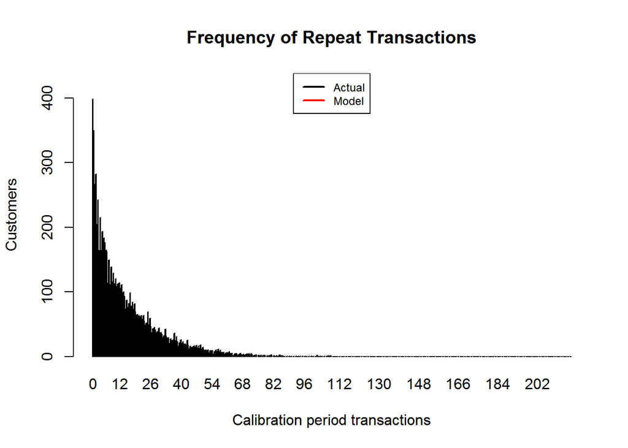

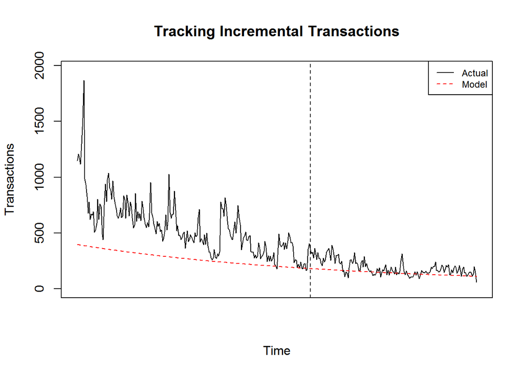

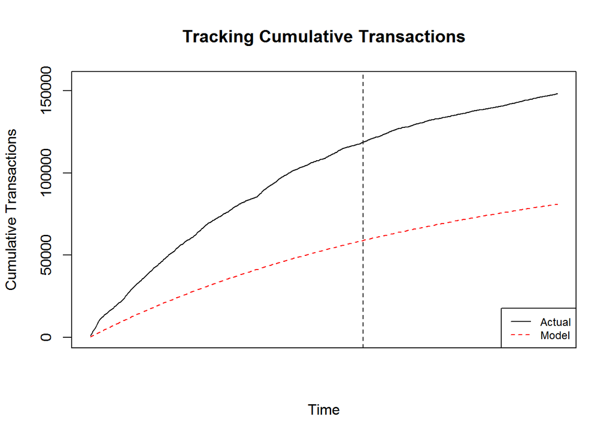

```r
########
#bg/bb model by day
cal.rf.matrix=dc.MakeRFmatrixCal(m1.data$cal$cbs[,"x"],m1.data$cal$cbs[,"t.x"],max(m1.data$cal$cbs[,"t.x"]))
m.bgbb.day=bgbb.EstimateParameters(cal.rf.matrix)
invisible(bgbb.PlotFrequencyInCalibration(m.bgbb.day,cal.rf.matrix))
actual.inc.repeat.transactions.d=gt[sample.cohort,] %>% group_by(transaction_date) %>% summarize(val=n()) %>% select(-transaction_date) %>% as.data.frame()
actual.inc.repeat.transactions.d=as.vector(actual.inc.repeat.transactions.d$val)
invisible(bgbb.PlotTrackingInc(m.bgbb.day,cal.rf.matrix,actual.inc.repeat.transactions.d))
invisible(bgbb.PlotTrackingCum(m.bgbb.day,cal.rf.matrix,cumsum(actual.inc.repeat.transactions.d)))
##very poor fit
```

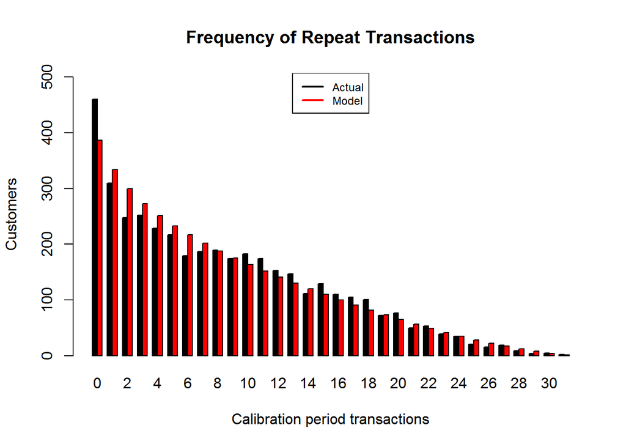

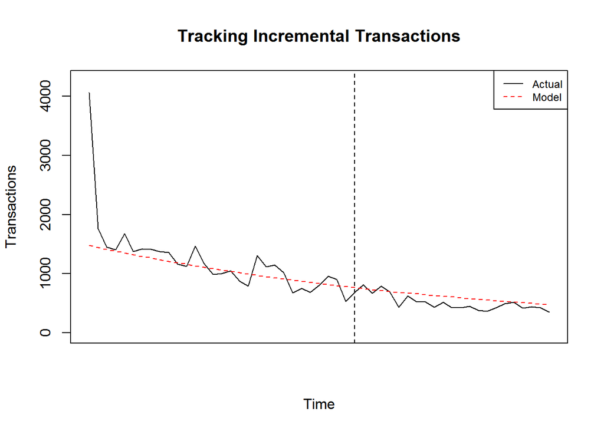

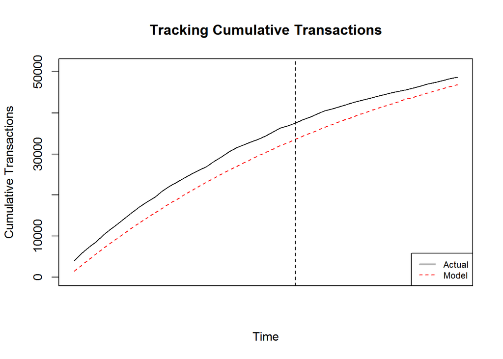

```r
#bg/bb model by week
cal.rf.matrix.week=dc.MakeRFmatrixCal(m3.data$cal$cbs[,"x"],m3.data$cal$cbs[,"t.x"],max(m3.data$cal$cbs[,"t.x"]))
m.bgbb.week=bgbb.EstimateParameters(cal.rf.matrix.week)
invisible(bgbb.PlotFrequencyInCalibration(m.bgbb.week,cal.rf.matrix.week))

actual.inc.repeat.transactions=gt.sample %>% group_by(transaction_date) %>% summarize(val=n()) %>% select(-transaction_date) %>% as.data.frame()
actual.inc.repeat.transactions=as.vector(actual.inc.repeat.transactions$val)
invisible(bgbb.PlotTrackingInc(m.bgbb.week,cal.rf.matrix.week,actual.inc.repeat.transactions))
invisible(bgbb.PlotTrackingCum(m.bgbb.week,cal.rf.matrix.week,cumsum(actual.inc.repeat.transactions)))

##a lot better than the previous, seems to converge in the end, will be used for LTV estimation
```

# 4. Building a model for residual discounted lifetime value for all customers

These models use discounted expected residual transactions, constant transaction value (different for each customer, following a gamma-gamma model), and an annual discount rate of 15% (corresponding to a continuous rate of 0.0027)

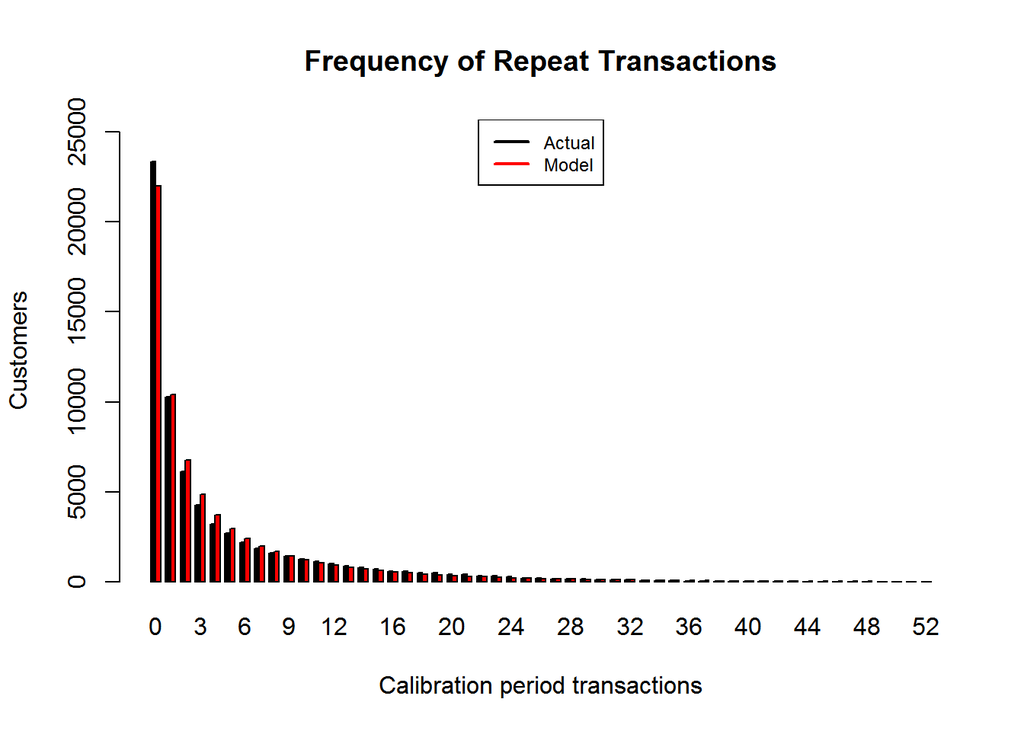

```r
#building the model with all the data
elog=gt %>% mutate(transaction_date=as.integer(difftime(transaction_date,min(transaction_date),units="weeks"))) %>% group_by(id,transaction_date) %>% summarize(value=sum(value)) %>% mutate(transaction_date=starting.date+7*transaction_date)
elog=data.frame(cust=elog$id,date=elog$transaction_date,sales=elog$value)
m.data=dc.ElogToCbsCbt(elog,per="week",merge.same.date = TRUE,statistic="freq")
rf.matrix=dc.MakeRFmatrixCal(m.data$cal$cbs[,"x"],m.data$cal$cbs[,"t.x"],max(m.data$cal$cbs[,"t.x"]))
m.bgbb.final=bgbb.EstimateParameters(rf.matrix)
bgbb.PlotFrequencyInCalibration(m.bgbb.final,rf.matrix) #this time it seems to give a better fit

#calculating discounted expected residual transactions, for all customers in the database
DERT=bgbb.DERT(m.bgbb.final,m.data$cal$cbs[,"x"],m.data$cal$cbs[,"t.x"],m.data$cal$cbs[,"T.cal"],0.0027)

#calculating discounted expected residual transactions, for a new customer
DERT.new=bgbb.DERT(m.bgbb.final,0,0,0,0.0027)


#calculating spending per customer, g/g model
spend.data=elog %>% group_by(cust) %>% summarize(m.x.vector=mean(sales),x.vector=n())
m.spend=spend.EstimateParameters(spend.data$m.x.vector,spend.data$x.vector)
cust.spend=spend.expected.value(m.spend, spend.data$m.x.vector, spend.data$x.vector)
new.spend=m.spend[1]*m.spend[2]*m.spend[3] #this is the expected value from a gamma distribution

#finally, calculating customer lifetime value
LTV.custs=DERT*cust.spend
LTV.new=DERT.new*new.spend
```

#### Estimated discounted lifetime value for an average new customer

```r
print(LTV.new)
```

```
## [1] 1172.118
```

#### Top-50 most profitable customers, by estimated residual discounted lifetime value

```r
print(head(LTV.custs[order(-LTV.custs)],50))
```

```
## 9,25312E+11  1,1068E+12    3,03E+11 6,34028E+11 7,21808E+11 2,81776E+11
##    33204.12    32099.21    26090.04    21434.40    19560.89    19409.34
## 2,29906E+11 4,20536E+11 5,48348E+11  8,3058E+11 2,07498E+11  1104335632
##    17942.73    17716.17    16860.79    16321.45    16289.34    16108.91
## 2,81256E+11  3,2634E+11 5,01652E+11 5,15472E+11 68589930828   891374306
##    15893.91    15372.69    14837.63    14704.26    14504.96    14361.72
## 2,56328E+11 5,67958E+11  2,1239E+11  7,4892E+11 4,86074E+11 28404453028
##    14297.56    14247.84    14112.25    14059.35    14033.10    13361.16
## 4,60518E+11 7,06944E+11 1,10179E+12 9,17466E+11 2,46146E+11 2,44948E+11
##    13284.56    13062.53    13046.77    13024.65    12841.77    12733.60
##  9,4676E+11  9,9178E+11 9,88004E+11  3,6662E+11 6,56986E+11 9,98032E+11
##    12435.58    12355.35    12172.37    11827.23    11793.18    11785.62
## 5,85042E+11 7,06208E+11 9,27862E+11  1,0104E+11 6,56342E+11 7,21618E+11
##    11741.13    11644.37    11366.79    11243.05    11068.49    11041.91
## 1,10977E+12 1,06194E+12  2,6619E+11  3,2936E+11 1,11475E+12 1,02063E+12
##    10970.73    10947.03    10932.01    10840.56    10753.20    10738.40
## 2,55486E+11 1,02389E+12
##    10703.70    10676.80
```

# 5. Summary statistics and visualizations

```r
#most common payments
print("Most common payments")
```

```
## [1] "Most common payments"
```

```r
print(head(table(gt$value)[order(-table(gt$value))]))
```

```
##
##     20     50    100    200    300    500
## 368622 365886 166249  94120  27420  12797
```

```r
#estimating average paying lifecycle
last.date=max(gt$transaction_date)
churned.users=gt %>% group_by(id) %>% summarize(recency=as.integer(last.date-max(transaction_date))) %>% filter(recency>=90)
churned.users.ids=unique(churned.users$id)
paying.cycles=gt %>% filter(install_date>=min(gt$transaction_date)) %>% filter(!(id %in% churned.users.ids)) %>% group_by(id) %>% summarize(paycycle=as.integer(max(transaction_date)-min(transaction_date)))
print(paste0(paste0("Average observed paying cycle: ",round(mean(paying.cycles$paycycle),2))," days"));print(paste0(paste0("Median observed paying cycle: ",round(median(paying.cycles$paycycle),2))," days"))
```

```
## [1] "Average observed paying cycle: 173.58 days"
```

```
## [1] "Median observed paying cycle: 197 days"
```

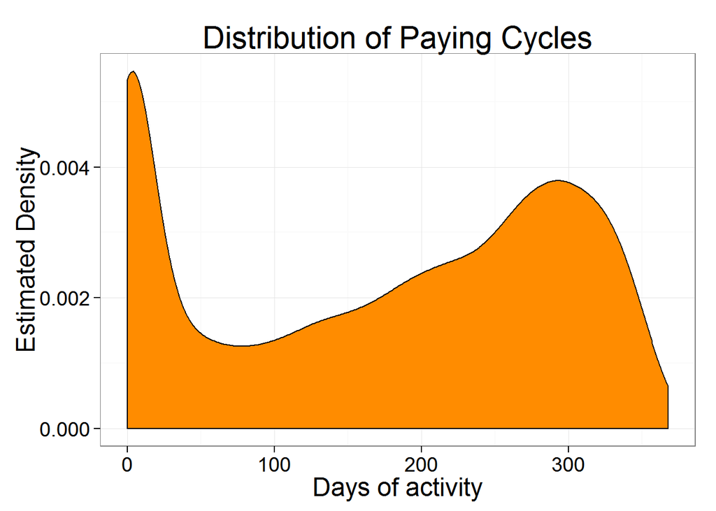

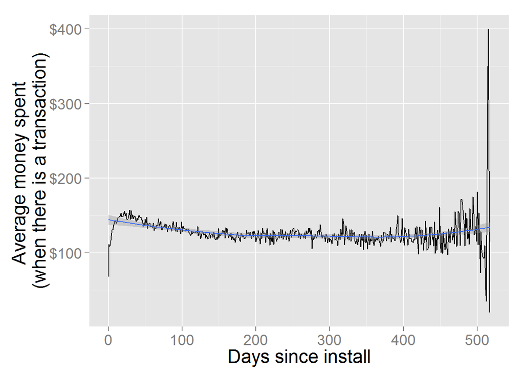

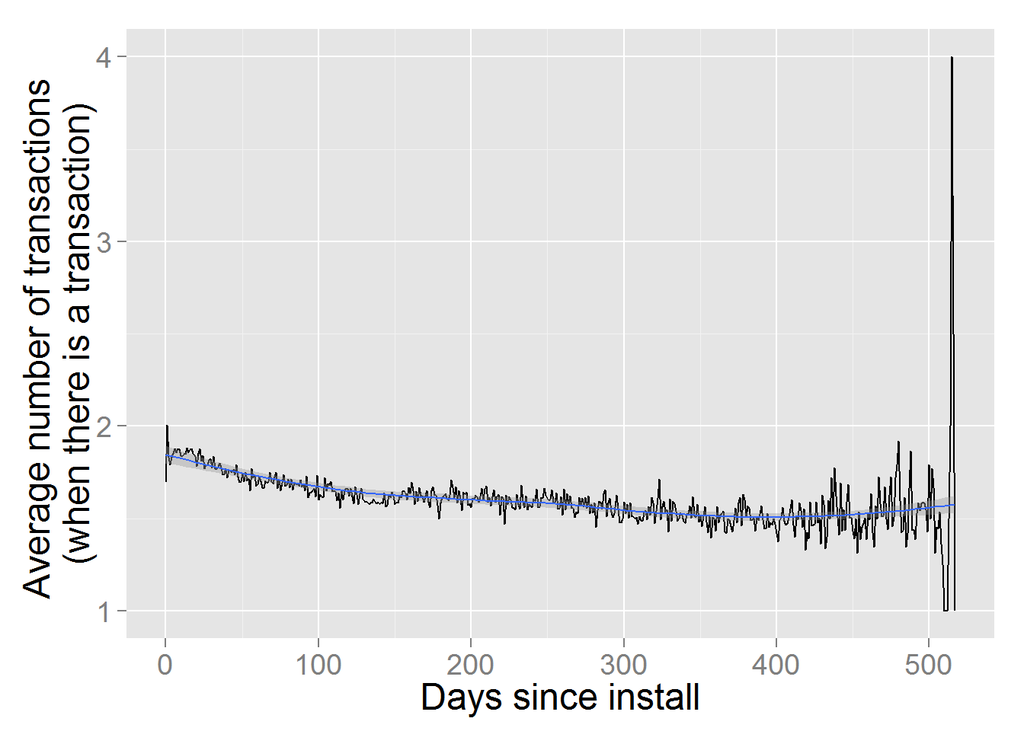

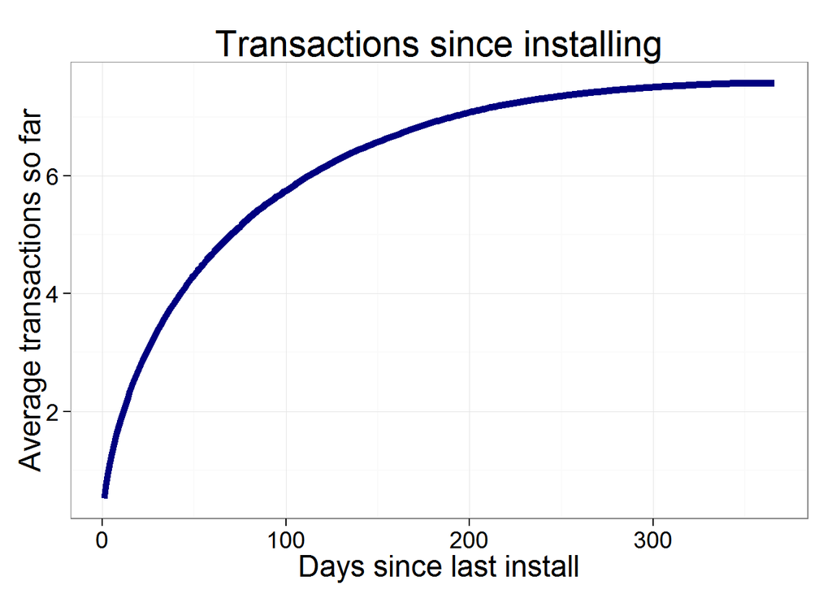

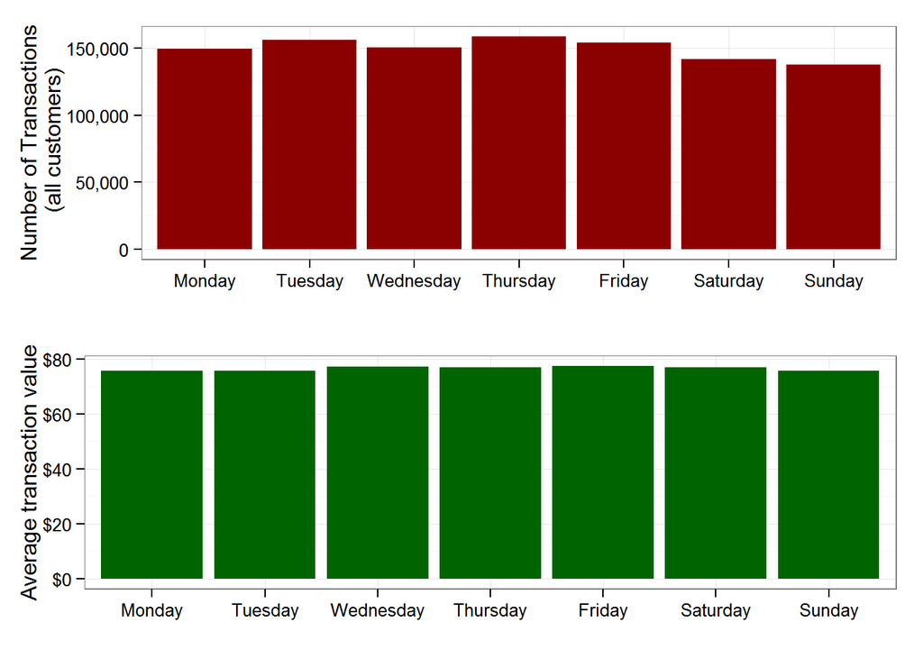

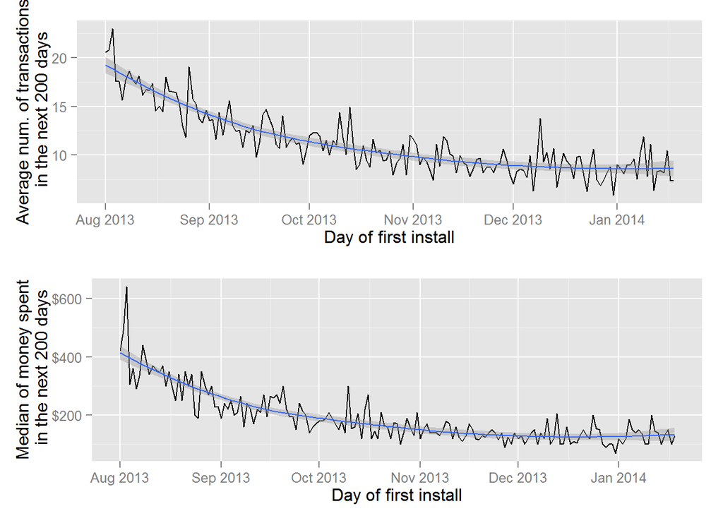

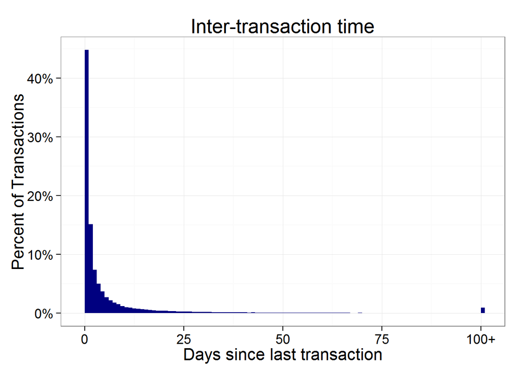

```r
ggplot(paying.cycles,aes(paycycle))+geom_density(fill='darkorange')+xlab("Days of activity")+ylab("Estimated Density")+theme_bw(base_size=18)+ggtitle("Distribution of Paying Cycles")

#average transactions and value by daily cohorts
pl=gt %>% group_by(id,transaction_date,install_date) %>% summarize(value=sum(value)) %>% mutate(trans.days.since.inst=as.numeric(transaction_date-install_date)) %>% group_by(trans.days.since.inst) %>% summarize(mean.val=mean(value))
ggplot(pl,aes(x=trans.days.since.inst,y=mean.val))+geom_line()+geom_smooth()+xlab("Days since install")+ylab("Average money spent \n(when there is a transaction)")+scale_y_continuous(label=dollar)+theme(text = element_text(size=18))

pl=gt %>% group_by(id,transaction_date,install_date) %>% summarize(n.trans=n()) %>% mutate(trans.days.since.inst=as.numeric(transaction_date-install_date)) %>% group_by(trans.days.since.inst) %>% summarize(mean.n.trans=mean(n.trans))
ggplot(pl,aes(x=trans.days.since.inst,y=mean.n.trans))+geom_line()+geom_smooth()+xlab("Days since install")+ylab("Average number of transactions \n(when there is a transaction)")+theme(text = element_text(size=18))

#average accumulated transactions
temp=gt %>% filter(install_date>=min(gt$transaction_date)) %>% group_by(id,transaction_date,install_date) %>% summarize(n.trans=n()) %>% mutate(trans.days.since.inst=as.numeric(transaction_date-install_date)) %>% arrange(id,trans.days.since.inst)
pl=temp %>% group_by(id,trans.days.since.inst) %>% summarize(n.trans=sum(n.trans)) %>% group_by(id) %>% mutate(cum.trans=cumsum(n.trans)) %>% select(-n.trans)
pl=temp %>% mutate(id2=paste0(id,as.numeric(install_date))) %>% group_by(id2) %>% mutate(cum.trans=cumsum(n.trans)) %>% select(id2,trans.days.since.inst,cum.trans)

custs.zero.order=pl %>% filter(trans.days.since.inst==0)
custs.zero.order=as.vector(unique(custs.zero.order$id2))
custs.no.zero=as.vector(unique(pl$id2))
custs.no.zero=custs.no.zero[!(custs.no.zero %in% custs.zero.order)]
added.cust.zero=data.frame(id2=custs.no.zero, trans.days.since.inst=rep(0,length(custs.no.zero)), cum.trans=rep(0,length(custs.no.zero)))
pl=rbind(pl,added.cust.zero)
pl=as.data.frame(pl)

df=data.frame(days=seq(1,max(pl$trans.days.since.inst)),cum.avg.trans=rep(NA,max(pl$trans.days.since.inst)))
for (i in 1:dim(df)[1]){
  d=df$days[i]
  tr=pl %>% filter(trans.days.since.inst<=d) %>% group_by(id2) %>% filter(trans.days.since.inst==max(trans.days.since.inst))
  tr=mean(tr$cum.trans)
  df$cum.avg.trans[i]=tr
}

ggplot(df,aes(x=days,y=cum.avg.trans))+geom_line(color="navy",size=2)+theme_bw(base_size=18)+xlab("Days since last install")+ylab("Average transactions so far")+ggtitle("Transactions since installing")

#values by day of the week
pl=gt %>% mutate(day=weekdays(transaction_date)) %>% group_by(day) %>% summarize(trans=n(),avg.val=mean(value))
pl=data.frame(day=c("Monday","Tuesday","Wednesday","Thursday","Friday","Saturday","Sunday")) %>% left_join(pl)
pl$d=1:7
pl$d=as.factor(pl$d)
levels(pl$d)=pl$day

p1=ggplot(pl,aes(d,trans))+geom_bar(stat="identity",fill="darkred")+xlab("")+ylab("Number of Transactions\n (all customers)")+scale_y_continuous(label=comma)+theme_bw()
p2=ggplot(pl,aes(d,avg.val))+geom_bar(stat="identity",fill="darkgreen")+xlab("")+ylab("Average transaction value")+scale_y_continuous(label=dollar)+theme_bw()
grid.arrange(p1,p2)

#taking cohorts by day of install
cohorts=gt %>% filter(install_date>=min(gt$transaction_date)) %>% group_by(id) %>% mutate(first.inst=min(install_date)) %>% mutate(days.since.inst=as.integer(transaction_date-first.inst))
cutoff=max(gt$transaction_date)-200
cohorts=cohorts %>% filter(first.inst<=cutoff) %>% filter(days.since.inst<=200)
pl=cohorts %>% group_by(id,first.inst) %>% summarize(trans=n()) %>% group_by(first.inst) %>% summarize(mean.n.trans=mean(trans))
p1=ggplot(pl,aes(first.inst,mean.n.trans))+geom_line()+geom_smooth()+ylab("Average num. of transactions\n in the next 200 days")+xlab("Day of first install")+scale_x_date(labels=date_format("%b %Y"))


pl=cohorts %>% group_by(id,first.inst) %>% summarize(money=sum(value)) %>% group_by(first.inst) %>% summarize(money=median(money))
p2=ggplot(pl,aes(first.inst,money))+geom_line()+geom_smooth()+ylab("Median of money spent\n in the next 200 days")+xlab("Day of first install")+scale_x_date(labels=date_format("%b %Y"))+scale_y_continuous(label=dollar)

grid.arrange(p1,p2)


#time since last transaction
pl=gt %>% arrange(id,transaction_date) %>% group_by(id) %>% mutate(lapse=as.integer(transaction_date-lag(transaction_date))) %>% filter(!is.na(lapse))
pl=data.frame(lapse=pl$lapse)
pl$lapse[pl$lapse>=100]=100
ggplot(pl,aes(lapse))+geom_histogram(binwidth=1,fill="navy",aes(y=..count../sum(..count..)))+scale_x_continuous(breaks=c(0,25,50,75,100),labels=c(0,25,50,75,"100+"))+theme_bw(base_size=16)+scale_y_continuous(label=percent)+ylab("Percent of Transactions")+xlab("Days since last transaction")+ggtitle("Inter-transaction time")
```

# 6. Users at risk of defecting

```r
#detecting at which moment a user is more likely to abandon
possible.situations=expand.grid(x=1:30,t.x=1:30,n.cal=1:30)

#filtering impossible cases
possible.situations=possible.situations %>% filter(x<=t.x) %>% filter(t.x<=n.cal)

#filtering unlikely cases
possible.situations=possible.situations %>% filter(!(x==1 & t.x>5)) %>% filter(x!=t.x) %>% filter((x/t.x)<=.7) %>% arrange(x,t.x,n.cal)

#doing the calculations
possible.situations$p=bgbb.PAlive(m.bgbb.final, possible.situations$x, possible.situations$t.x, possible.situations$n.cal)
possible.situations=possible.situations %>% group_by(x,t.x) %>% mutate(p.change=-(p-lag(p)))
possible.situations=possible.situations %>% filter(!is.na(p.change)) %>%  filter(p>=.5) %>% group_by(x,t.x) %>% filter(p.change==max(p.change)) %>% as.data.frame() %>% arrange(desc(p.change))

pl=data.frame(possible.situations$x,possible.situations$t.x,possible.situations$n.cal-possible.situations$t.x,possible.situations$p,possible.situations$p.change)
names(pl)=c("Weeks with Transactions","Week of Last Transaction (since 1st trans)","Weeks without transaction","Probability of continuing payments","Decrease since last week")

library(xtable)
pl=xtable(pl[1:35,])
print(pl,floating=FALSE,type="html",include.rownames = FALSE)
```

| Weeks with Transactions | Week of Last Transaction (since 1st trans) | Weeks without transaction | Probability of continuing payments | Decrease since last week |
| --- | --- | --- | --- | --- |
| 18 | 26 | 2 | 0.63 | 0.21 |
| 16 | 23 | 2 | 0.64 | 0.20 |
| 19 | 28 | 2 | 0.64 | 0.20 |
| 14 | 20 | 2 | 0.64 | 0.20 |
| 14 | 23 | 3 | 0.50 | 0.20 |
| 15 | 25 | 3 | 0.51 | 0.20 |
| 17 | 25 | 2 | 0.65 | 0.20 |
| 16 | 27 | 3 | 0.51 | 0.20 |
| 15 | 22 | 2 | 0.65 | 0.19 |
| 8 | 12 | 3 | 0.50 | 0.19 |
| 18 | 27 | 2 | 0.65 | 0.19 |
| 9 | 14 | 3 | 0.51 | 0.19 |
| 10 | 16 | 3 | 0.51 | 0.19 |
| 11 | 18 | 3 | 0.52 | 0.19 |
| 12 | 20 | 3 | 0.52 | 0.19 |
| 13 | 19 | 2 | 0.66 | 0.19 |
| 13 | 22 | 3 | 0.52 | 0.19 |
| 16 | 24 | 2 | 0.66 | 0.19 |
| 14 | 24 | 3 | 0.53 | 0.19 |
| 15 | 26 | 3 | 0.53 | 0.19 |
| 17 | 26 | 2 | 0.67 | 0.18 |
| 14 | 21 | 2 | 0.67 | 0.18 |
| 11 | 16 | 2 | 0.66 | 0.18 |
| 18 | 28 | 2 | 0.67 | 0.18 |
| 15 | 23 | 2 | 0.67 | 0.18 |
| 15 | 27 | 3 | 0.55 | 0.18 |
| 14 | 25 | 3 | 0.55 | 0.18 |
| 13 | 23 | 3 | 0.55 | 0.18 |
| 12 | 18 | 2 | 0.67 | 0.18 |
| 12 | 21 | 3 | 0.55 | 0.18 |
| 11 | 19 | 3 | 0.55 | 0.18 |
| 10 | 17 | 3 | 0.54 | 0.18 |
| 9 | 15 | 3 | 0.54 | 0.18 |
| 8 | 13 | 3 | 0.54 | 0.18 |
| 7 | 11 | 3 | 0.54 | 0.18 |

# 7. Finding segments

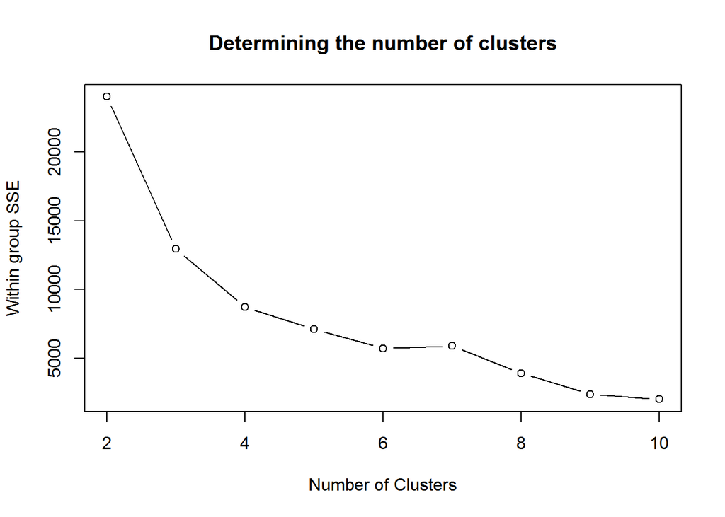

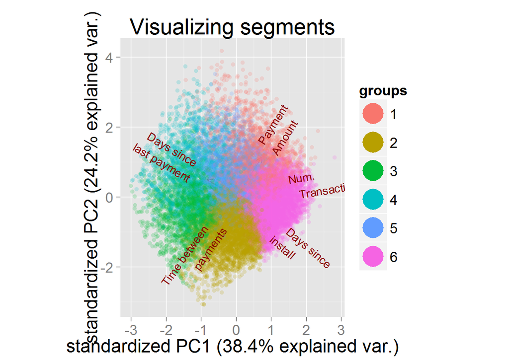

```r
#singling out churned users
last.date=max(gt$transaction_date)
churned.users=gt %>% group_by(id) %>% summarize(recency=as.integer(last.date-max(transaction_date))) %>% filter(recency>=90)
churned.users.ids=unique(churned.users$id)
remaining.users=gt[!(gt$id %in% churned.users.ids),]

#singling out new customers
new.custs=remaining.users %>% group_by(id) %>% summarize(trans=n()) %>% filter(trans==1) %>% select(id) %>% as.vector()
old.custs=remaining.users[!(remaining.users$id %in% new.custs$id),]

#average payment, average number of transactions, tenure, recency
old.custs.vars=old.custs %>% group_by(id) %>% summarize(avg.pay=mean(value),n.trans=n(),tenure=as.integer(max(transaction_date)-min(install_date)),recency=as.integer(last.date-max(transaction_date)))

#inter-transaction time
inter.t.t=old.custs %>% arrange(id,transaction_date) %>% group_by(id) %>% mutate(lapse=as.integer(transaction_date-lag(transaction_date))) %>% filter(!is.na(lapse)) %>% group_by(id) %>% summarize(inter.t.t=mean(lapse))
old.custs.vars=old.custs.vars %>% left_join(inter.t.t)

#standardizing variables
clust.data=as.data.frame(old.custs.vars)
clust.data$id=NULL
clust.data$avg.pay=log(clust.data$avg.pay)
clust.data$n.trans=log(clust.data$n.trans)
clust.data$inter.t.t=log(clust.data$inter.t.t+1)

library(caret)
pp=preProcess(clust.data,method=c("center","scale"))
clust.data=predict(pp,clust.data)
clust.data$inter.t.t=clust.data$inter.t.t/1.5

#determining principal components to use later
names(clust.data)=c("Payment \nAmount","Num. \nTransactions","Days since \ninstall","Days since \nlast payment","Time between \npayments")
pc.data=prcomp(clust.data)
var.axis1=(pc.data$sdev[1]^2)/(sum(pc.data$sdev^2))
var.axis2=(pc.data$sdev[2]^2)/(sum(pc.data$sdev^2))

#determining the number of clusters
set.seed(1)
clusts.sse=rep(NA,9)
for (i in 2:10){
  clusts.sse[i-1]=kmeans(clust.data,centers=i,iter.max=20,nstart=10)$withinss
}
plot(x=2:10,y=clusts.sse,type='b',xlab="Number of Clusters",ylab="Within group SSE",main="Determining the number of clusters")

#clustering with optimal number of segments
set.seed(1)
clusts6=kmeans(clust.data,centers=6,iter.max=30,nstart=20)

#visualizing these clusters
library(ggbiplot)
ggbiplot(pc.data,varname.size=4,labels.size=.1,var.axes=TRUE,alpha=0.2,groups=as.factor(clusts6$cluster),elipse=TRUE)+ guides(colour = guide_legend(override.aes = list(size=10,alpha=1)))+ggtitle("Visualizing segments")+theme(text = element_text(size=18))
```

# 8. Examining the obtained segments

```r
segmented=old.custs.vars
segment=as.factor(paste0("Segment number ",clusts6$cluster))
segmented$segment=segment
segmented=segmented %>% left_join(as.data.frame(table(segment))) %>% select(-id,-segment)
names(segmented)=c("Payment Amount","Num. Transactions","Days since install","Days since last payment","Time between payments","Users in segment")
segmented$ID=NULL
by(segmented, segment, apply,2,mean)
```

```
## segment: Segment number 1
##          Payment Amount       Num. Transactions      Days since install
##               176.20961                30.06844               302.70627
## Days since last payment   Time between payments        Users in segment
##                25.44962                12.42759              2104.00000
## --------------------------------------------------------
## segment: Segment number 2
##          Payment Amount       Num. Transactions      Days since install
##                43.86529                13.63050               389.42209
## Days since last payment   Time between payments        Users in segment
##                17.26737                33.71648              3613.00000
## --------------------------------------------------------
## segment: Segment number 3
##          Payment Amount       Num. Transactions      Days since install
##                41.03132                 6.47460               288.67780
## Days since last payment   Time between payments        Users in segment
##                61.93133                53.47807              2126.00000
## --------------------------------------------------------
## segment: Segment number 4
##          Payment Amount       Num. Transactions      Days since install
##               58.963895                8.333157               68.568482
## Days since last payment   Time between payments        Users in segment
##               32.516658                5.234232             1891.000000
## --------------------------------------------------------
## segment: Segment number 5
##          Payment Amount       Num. Transactions      Days since install
##               70.467202               41.004320              335.324334
## Days since last payment   Time between payments        Users in segment
##               65.324694                8.533478             2778.000000
## --------------------------------------------------------
## segment: Segment number 6
##          Payment Amount       Num. Transactions      Days since install
##               69.447950               77.345671              424.175920
## Days since last payment   Time between payments        Users in segment
##               13.970857                5.580742             4701.000000
```

These segments consider only users that have a high probability of still being active.

Describing these segments:

- Segment 1: high payments but which don’t happen very often, old users.
- Segment 2: active old users who make low infrequent payments.
- Segment 3: low infrequent payments and abandoning. Less attractive segment.
- Segment 4: new users who made frequent small payments and are abandoning. Attention needs to be payed to this segment.
- Segment 5: middle-value payments that happen frequently, but are stopping. This segment needs to be monitored, as users are at risk of abandoning.
- Segment 6: middle-value payments that happen very frequently, from old users, recently active. This seems to be the most valuable segment.